# Project: Investigate a Dataset - [Tmdb movie Data]

- Introduction
- Data Wrangling
- Exploratory Data Analysis
- Conclusions

## Introduction

### Dataset Description

Tmdb Movie Data is a collection of films and their details like cast crew, directors etc. The dataset contains 10865 films released between the year 1960 and 2015.

Below is a list of columns and their description:

| Column Name | Description | Used ? | Multiple Values ? |
| --- | --- | --- | --- |
| id | Unique dataset identifier | Yes | No |
| imdb_id | IDDB unique identifier. Can be used to join to imdb data | No | No |
| popular | Movie popularity rating | Yes | No |
| budget | Cost used to produce film | Yes | No |
| revenue | Sales amount made when movies are sold / rented | Yes | No |
| original_title | Initial title used for the Movie. | No | No |
| cast | Actors/Perfomers in the film | No | Yes (\|) |
| homepage | Link to movie homepage | No | No |
| director | A person who directs how actors perform assigned roles. | Yes | Yes (\|) |
| tagline | One sentence catchphrase | No | No |
| keywords | Movie metadata/tags | No | Yes (\|) |
| overview | Short description about the film. | No | No |
| runtime | Length of the Movie in Minutes. | No | Yes (\|) |
| genres | Genre categories which the film falls into. | No | Yes (\|) |
| production_companies | Companies that produced the film. | No | Yes (\|) |
| release_date | The date when film was released. Format MM/DD/YY. | Yes | No |
| vote_count | Number of Votes | Yes | No |
| vote_average | Vote average | No | No |
| release_year | Year Movie was released. | No | No |
| budget_adj | budget adjested to inflation to reflect 2010 dollars | No | No |
| revenue_adj | revenue adjusted to reflect dollar values in 2010. | No | No |

### Question(s) for Analysis

1. Which Months are best/worst to release a Movie?
2. Which Directors can deliver best performing movies ?

```python
# Import packages to be used in Data Analysis

import pandas as pd
import numpy as np
import matplotlib.pyplot as plt
import seaborn as sns
%matplotlib inline
```

```python
# Upgrade pandas to use dataframe.explode() function.
# !pip install --upgrade pandas==0.25.0
```

## Data Wrangling

### General Properties

#### Read and view first few rows of the dataset

```python
# Read data from csv file and display the first 5 rows

df = pd.read_csv('tmdb-movies.csv')
df.head()
```

|  | id | imdb_id | popularity | budget | revenue | original_title | cast | homepage | director | tagline | ... | overview | runtime | genres | production_companies | release_date | vote_count | vote_average | release_year | budget_adj | revenue_adj |
| --- | --- | --- | --- | --- | --- | --- | --- | --- | --- | --- | --- | --- | --- | --- | --- | --- | --- | --- | --- | --- | --- |
| 0 | 135397 | tt0369610 | 32.985763 | 150000000 | 1513528810 | Jurassic World | Chris Pratt\|Bryce Dallas Howard\|Irrfan Khan\|Vi... | http://www.jurassicworld.com/ | Colin Trevorrow | The park is open. | ... | Twenty-two years after the events of Jurassic ... | 124 | Action\|Adventure\|Science Fiction\|Thriller | Universal Studios\|Amblin Entertainment\|Legenda... | 6/9/15 | 5562 | 6.5 | 2015 | 1.379999e+08 | 1.392446e+09 |
| 1 | 76341 | tt1392190 | 28.419936 | 150000000 | 378436354 | Mad Max: Fury Road | Tom Hardy\|Charlize Theron\|Hugh Keays-Byrne\|Nic... | http://www.madmaxmovie.com/ | George Miller | What a Lovely Day. | ... | An apocalyptic story set in the furthest reach... | 120 | Action\|Adventure\|Science Fiction\|Thriller | Village Roadshow Pictures\|Kennedy Miller Produ... | 5/13/15 | 6185 | 7.1 | 2015 | 1.379999e+08 | 3.481613e+08 |
| 2 | 262500 | tt2908446 | 13.112507 | 110000000 | 295238201 | Insurgent | Shailene Woodley\|Theo James\|Kate Winslet\|Ansel... | http://www.thedivergentseries.movie/#insurgent | Robert Schwentke | One Choice Can Destroy You | ... | Beatrice Prior must confront her inner demons ... | 119 | Adventure\|Science Fiction\|Thriller | Summit Entertainment\|Mandeville Films\|Red Wago... | 3/18/15 | 2480 | 6.3 | 2015 | 1.012000e+08 | 2.716190e+08 |
| 3 | 140607 | tt2488496 | 11.173104 | 200000000 | 2068178225 | Star Wars: The Force Awakens | Harrison Ford\|Mark Hamill\|Carrie Fisher\|Adam D... | http://www.starwars.com/films/star-wars-episod... | J.J. Abrams | Every generation has a story. | ... | Thirty years after defeating the Galactic Empi... | 136 | Action\|Adventure\|Science Fiction\|Fantasy | Lucasfilm\|Truenorth Productions\|Bad Robot | 12/15/15 | 5292 | 7.5 | 2015 | 1.839999e+08 | 1.902723e+09 |
| 4 | 168259 | tt2820852 | 9.335014 | 190000000 | 1506249360 | Furious 7 | Vin Diesel\|Paul Walker\|Jason Statham\|Michelle ... | http://www.furious7.com/ | James Wan | Vengeance Hits Home | ... | Deckard Shaw seeks revenge against Dominic Tor... | 137 | Action\|Crime\|Thriller | Universal Pictures\|Original Film\|Media Rights ... | 4/1/15 | 2947 | 7.3 | 2015 | 1.747999e+08 | 1.385749e+09 |

5 rows × 21 columns

#### Numeric value summary

Statistical summary including percentile, standard deviation, mean etc. of numeric values in the dataset.

From the describe output below, columns with value of zero in the min row will be replaced with the mean value of the colum excluding **NAN** values.

```python
# Summary of data

df.describe()
```

|  | id | popularity | budget | revenue | runtime | vote_count | vote_average | release_year | budget_adj | revenue_adj |
| --- | --- | --- | --- | --- | --- | --- | --- | --- | --- | --- |
| count | 10866.000000 | 10866.000000 | 1.086600e+04 | 1.086600e+04 | 10866.000000 | 10866.000000 | 10866.000000 | 10866.000000 | 1.086600e+04 | 1.086600e+04 |
| mean | 66064.177434 | 0.646441 | 1.462570e+07 | 3.982332e+07 | 102.070863 | 217.389748 | 5.974922 | 2001.322658 | 1.755104e+07 | 5.136436e+07 |
| std | 92130.136561 | 1.000185 | 3.091321e+07 | 1.170035e+08 | 31.381405 | 575.619058 | 0.935142 | 12.812941 | 3.430616e+07 | 1.446325e+08 |
| min | 5.000000 | 0.000065 | 0.000000e+00 | 0.000000e+00 | 0.000000 | 10.000000 | 1.500000 | 1960.000000 | 0.000000e+00 | 0.000000e+00 |
| 25% | 10596.250000 | 0.207583 | 0.000000e+00 | 0.000000e+00 | 90.000000 | 17.000000 | 5.400000 | 1995.000000 | 0.000000e+00 | 0.000000e+00 |
| 50% | 20669.000000 | 0.383856 | 0.000000e+00 | 0.000000e+00 | 99.000000 | 38.000000 | 6.000000 | 2006.000000 | 0.000000e+00 | 0.000000e+00 |
| 75% | 75610.000000 | 0.713817 | 1.500000e+07 | 2.400000e+07 | 111.000000 | 145.750000 | 6.600000 | 2011.000000 | 2.085325e+07 | 3.369710e+07 |
| max | 417859.000000 | 32.985763 | 4.250000e+08 | 2.781506e+09 | 900.000000 | 9767.000000 | 9.200000 | 2015.000000 | 4.250000e+08 | 2.827124e+09 |

#### Data Rows and columns

pandas shape returns a tuple with first item being the rows and the second item being the columns

```python
# Get number of rows and columns in the dataset
df.shape
```

```
(10866, 21)
```

#### Data basic information

info method returns the data column names including their data types and number of non null rows

```python
# Basic data information i.e. data type etc

df.info()
```

```
<class 'pandas.core.frame.DataFrame'>
RangeIndex: 10866 entries, 0 to 10865
Data columns (total 21 columns):
 #   Column                Non-Null Count  Dtype
---  ------                --------------  -----
 0   id                    10866 non-null  int64
 1   imdb_id               10856 non-null  object
 2   popularity            10866 non-null  float64
 3   budget                10866 non-null  int64
 4   revenue               10866 non-null  int64
 5   original_title        10866 non-null  object
 6   cast                  10790 non-null  object
 7   homepage              2936 non-null   object
 8   director              10822 non-null  object
 9   tagline               8042 non-null   object
 10  keywords              9373 non-null   object
 11  overview              10862 non-null  object
 12  runtime               10866 non-null  int64
 13  genres                10843 non-null  object
 14  production_companies  9836 non-null   object
 15  release_date          10866 non-null  object
 16  vote_count            10866 non-null  int64
 17  vote_average          10866 non-null  float64
 18  release_year          10866 non-null  int64
 19  budget_adj            10866 non-null  float64
 20  revenue_adj           10866 non-null  float64
dtypes: float64(4), int64(6), object(11)
memory usage: 1.7+ MB
```

#### Data Duplication check.

Duplication in data can lead to misleading conclusion. This is undesired because the organization can incur losses financially and/or reputational damage.

From the below, only 1 record is duplicated

```python
# Count of duplicated records
df.duplicated().sum()
```

```
1
```

### Data Cleaning

#### Remove columns not used in this analysis

To answer the questions posed in the introduction, some columns from the dataset will not be required.

To optimize on computational resources, these extra columns will be dropped thus the amount of data required to be loaded to the memory will reduce.

Below are columns that will be dropped.

```python
# Remove columns not used in the data analysis
df.drop(['homepage', 'tagline', 'overview', 'original_title', 'imdb_id', 'runtime', 'cast', 'production_companies', 'keywords'], axis=1, inplace=True)

# check number of columns remaining in the dataset
df.shape[1]
```

```
12
```

#### Remove Duplicates

Once the unnecessary columns have been dropped, duplicates in the dataset can be removed.

```python
# Remove duplicated from dataset
df.drop_duplicates(inplace=True)

# Confirm column count
df.shape[0]
```

```
10865
```

### Dealing with missing values and zero values in the dataset

#### Missing Values

Replace null values with NA string. This will prevent values from rows with NA not to be ignored while doing visualization

```python
# Print list of columns with null values
print(df.columns[df.isnull().any()].tolist())

# Replace null values with NA
df.fillna('NA', inplace=True)

# Check if there is any column with null values
print(df.columns[df.isnull().any()].tolist())
```

```
['director', 'genres']
[]
```

#### Replace zero(0) values with mean of the column.

Whenever we have zero value in any numeric column, the code below will substitute it with the mean of the column.

```python
# List from dataset with numeric values
numeric_val_list = ['popularity', 'budget', 'revenue', 'vote_count', 'vote_average', 'budget_adj', 'revenue_adj']

def replace_zero_with_mean(lst):
    """
        Replace zero values on the dataframe with the mean values.

        Input:
            lst list - List of columns with numeric values in the DataFrame

    """

    # Iterate over list and replace zero values with mean of the column
    for col_name in lst:
        col_name_mean = df[col_name].mean(skipna=True)
        df[col_name].replace(0, col_name_mean, inplace=True)

def check_for_zeros(lst):
    """
        Check for zero values in the Dataframe for columns provided

        Input:
            lst list - List of columns with numeric values in the DataFrame
    """

    # Iterate over the list and check if zero value exists
    for col_name in lst:
        zero_val_lst = []
        if df[df[col_name] == 0].shape[0] > 0:
            zero_val_lst.append(col_name)

    if len(zero_val_lst) == 0:
        print('No zero value in the list ')
    else:
        print('Zero values present in the columns: {}'.format(zero_val_lst))

# Check columns with zero values
check_for_zeros(numeric_val_list)

#Replace zero values with mean
replace_zero_with_mean(numeric_val_list)

# Check to confirm zero values have been replaced
check_for_zeros(numeric_val_list)
```

```
Zero values present in the columns: ['revenue_adj']
No zero value in the list
```

### Change Data Types

- Release date from string to date_time  
  Enable date calculation when doing analysis
- id from int to string.  
  Will ensure **id** column is not used when summary statistics for numerical values is done.

```python
# Change release date to datetime data type
df['release_date'] = pd.to_datetime(df['release_date'])

# Convert ID data type from integer to string
df['id'] = df['id'].astype('str')

# Check date format
df['release_date'].head()
```

```
0   2015-06-09
1   2015-05-13
2   2015-03-18
3   2015-12-15
4   2015-04-01
Name: release_date, dtype: datetime64[ns]
```

### Add columns

New columns that are used to analyze data in a broader perpective are added.

Two columns are related to month, while the third one is for profit calculation.

```python
import calendar

# create month column with numeric month value from release date
df['month'] = df['release_date'].apply(lambda x: x.month)

# used logic from sources link number 3. to convert numeric month value to abbreviated month value
df['month_name'] = df['month'].apply(lambda x: calendar.month_abbr[x])

# Profit calculated field using revenue and budget
df['profit'] = df['revenue'] - df['budget']
```

Checking data to confirm that the new columns are present in the DataFrame

```python
df.head()
```

|  | id | popularity | budget | revenue | director | genres | release_date | vote_count | vote_average | release_year | budget_adj | revenue_adj | month | month_name | profit |
| --- | --- | --- | --- | --- | --- | --- | --- | --- | --- | --- | --- | --- | --- | --- | --- |
| 0 | 135397 | 32.985763 | 150000000.0 | 1.513529e+09 | Colin Trevorrow | Action\|Adventure\|Science Fiction\|Thriller | 2015-06-09 | 5562 | 6.5 | 2015 | 1.379999e+08 | 1.392446e+09 | 6 | Jun | 1.363529e+09 |
| 1 | 76341 | 28.419936 | 150000000.0 | 3.784364e+08 | George Miller | Action\|Adventure\|Science Fiction\|Thriller | 2015-05-13 | 6185 | 7.1 | 2015 | 1.379999e+08 | 3.481613e+08 | 5 | May | 2.284364e+08 |
| 2 | 262500 | 13.112507 | 110000000.0 | 2.952382e+08 | Robert Schwentke | Adventure\|Science Fiction\|Thriller | 2015-03-18 | 2480 | 6.3 | 2015 | 1.012000e+08 | 2.716190e+08 | 3 | Mar | 1.852382e+08 |
| 3 | 140607 | 11.173104 | 200000000.0 | 2.068178e+09 | J.J. Abrams | Action\|Adventure\|Science Fiction\|Fantasy | 2015-12-15 | 5292 | 7.5 | 2015 | 1.839999e+08 | 1.902723e+09 | 12 | Dec | 1.868178e+09 |
| 4 | 168259 | 9.335014 | 190000000.0 | 1.506249e+09 | James Wan | Action\|Crime\|Thriller | 2015-04-01 | 2947 | 7.3 | 2015 | 1.747999e+08 | 1.385749e+09 | 4 | Apr | 1.316249e+09 |

## Exploratory Data Analysis

#### Distribution of key properties

Data distribution of key data properties shown below.

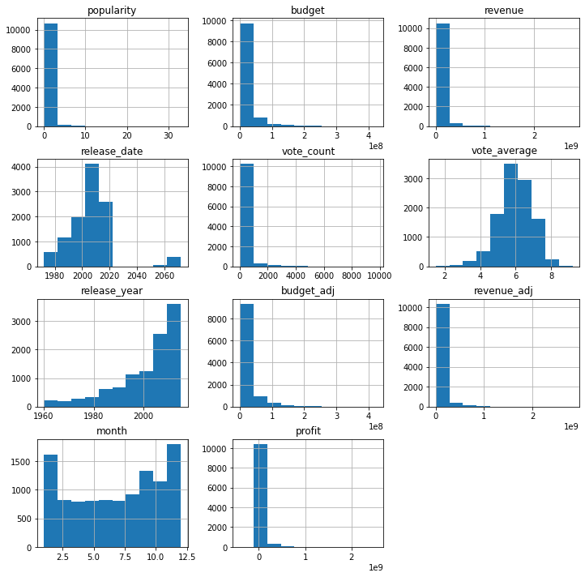

```python
df.hist(figsize=(12,12));
```

#### Revenue vs Budget Scatter Plot

There is positive correlation between Revenue, Budget and Profit.

From the figure below, we can conclude that when the budget is low, we expect low revenue and profit.

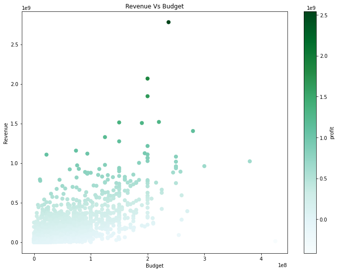

```python
ax = df.plot(x='budget', y='revenue',c='profit',
            kind='scatter', s=50, cmap='BuGn', figsize=(12,9),
            xlabel='Budget', ylabel='Revenue', title='Revenue Vs Budget', sharex=False);
```

#### Popularity vs Vote Count

There is a positive correlation between vote count and popularity with very few outliers.

A slight increase in popularity leads to a much higher vote count except for a few outliers where popularity is among the highest and the vote count is lower compared to others with low popularity.

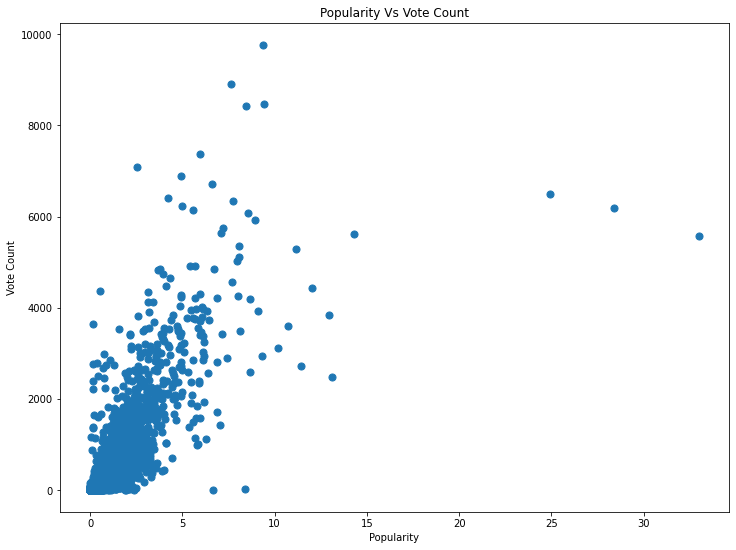

```python
ax = df.plot(x='popularity', y='vote_count',
            kind='scatter', s=50, figsize=(12,9),
            xlabel='Popularity', ylabel='Vote Count', title='Popularity Vs Vote Count');
```

### Which Month has high performing Movies ?

Within the year, some months have high number of holiday days which means people have extra time to devote to leisure activities. In this analysis, I will try to depict months with high movie performance which can be used to guide movie producers to target their release circle around these months.

Movie performance can be measured in terms of high revenues, low buget, high popularity etc

Calculating mean of numeric columns grouped by month. This will allow plotting monthly visualizations for comparison month on month. The resulting data is stored in a new DataFrame (df1). This Dataframe will be used throughout this section.

```python
# Columns with numeric values
cols = ['director', 'popularity', 'budget', 'revenue', 'vote_count', 'vote_average', 'budget_adj', 'revenue_adj', 'profit']

df1 = df.groupby(['month_name', 'month'], as_index=False)[cols].mean()

# Sort DataFrame by month
df1.sort_values(by='month', inplace=True)
```

From the graph below, the months of May to July and November to Dec have high budget spending. Similarly, low budget is observed in the months of January, August, September and October.

This analysis can be used to guide on which months movies can be produced the cheapest.

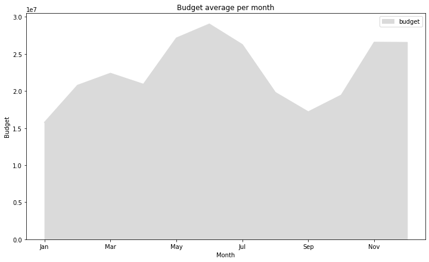

```python
ax = df1.plot.area('month_name', 'budget', title='Budget average per month', color='#dadada', figsize=(12,7));

ax.set_xlabel('Month')
ax.set_ylabel('Budget');
```

In the month of May to July and November to December revenue and profit is at the highest. The months of January and September have the lowest revenue and profit.

To increase chances of high profit margins, mvoies should be released close to the start of high revenue months.

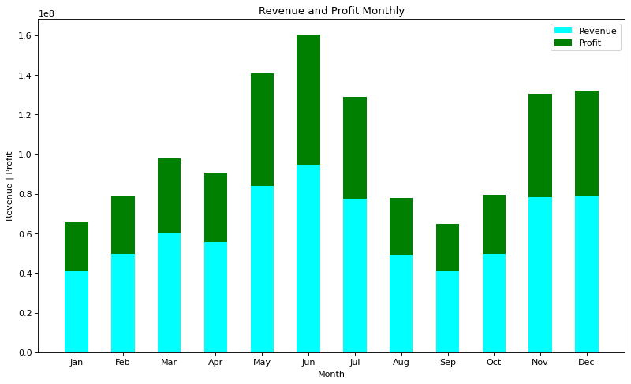

```python
x = df1['month_name']
y1 = df1['revenue']
y2 = df1['profit']

plt.figure(figsize=(12, 7), dpi=80)

plt.bar(x, y1, color='cyan', width=0.5)
plt.bar(x, y2, bottom=y1, color='green', width=0.5)

plt.xlabel('Month')
plt.ylabel('Revenue | Profit')
plt.legend(['Revenue', 'Profit'])
plt.title('Revenue and Profit Monthly')

plt.show()
```

From the scatter plot below, April, July and December have the highest vote counts while August and February have the lowest.

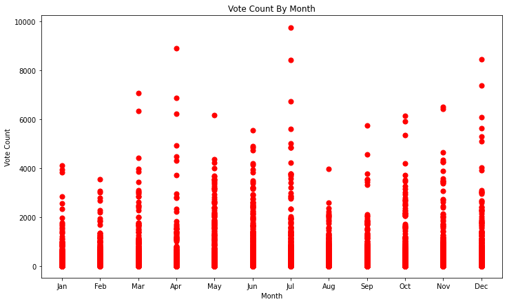

```python
ax = df.sort_values(by='month').plot.scatter('month_name', 'vote_count', title='Vote Count By Month', s=50, c='red', figsize=(12,7))

ax.set_xlabel('Month')
ax.set_ylabel('Vote Count');
```

### Which directors have high performing Movies

Quality of the Movie/film is sometimes attributed to the directors who produce those films.

In this analysis, I will be attempting to highlight best performing directors.

This can be useful in deciding the directors who can produce movies which are high performing.

A new DataFrame to hold the average values of numeric columns grouped by the director.

The dataframe is further reduced to retain only top 10 directors by movie profit.

```python
df2 = df.groupby('director', as_index=False)[cols].mean()

# Sort directors based on highest profits
df2.sort_values(by=['profit'], ascending=False, ignore_index=True, inplace=True)

# Top 10 Directors per Profit
df2 = df2.iloc[:10]

df2
```

|  | director | popularity | budget | revenue | vote_count | vote_average | budget_adj | revenue_adj | profit |
| --- | --- | --- | --- | --- | --- | --- | --- | --- | --- |
| 0 | Kyle Balda\|Pierre Coffin | 7.404165 | 7.400000e+07 | 1.156731e+09 | 2893.0 | 6.50 | 6.807997e+07 | 1.064192e+09 | 1.082731e+09 |
| 1 | Lee Unkrich | 2.711136 | 2.000000e+08 | 1.063172e+09 | 2924.0 | 7.50 | 2.000000e+08 | 1.063172e+09 | 8.631719e+08 |
| 2 | Andrew Stanton\|Lee Unkrich | 3.440519 | 9.400000e+07 | 8.646260e+08 | 3692.0 | 7.40 | 1.114231e+08 | 1.024887e+09 | 7.706260e+08 |
| 3 | Andrew Adamson\|Kelly Asbury\|Conrad Vernon | 2.191033 | 1.500000e+08 | 9.198388e+08 | 1676.0 | 6.50 | 1.731668e+08 | 1.061904e+09 | 7.698388e+08 |
| 4 | Roger Allers\|Rob Minkoff | 4.782688 | 4.500000e+07 | 7.882418e+08 | 3489.0 | 7.70 | 6.620002e+07 | 1.159592e+09 | 7.432418e+08 |
| 5 | Pierre Coffin\|Chris Renaud | 3.860335 | 7.250000e+07 | 7.571379e+08 | 4143.5 | 7.05 | 7.006927e+07 | 7.260897e+08 | 6.846379e+08 |
| 6 | Colin Trevorrow | 16.696886 | 7.537500e+07 | 7.587683e+08 | 2951.5 | 6.60 | 6.935612e+07 | 6.981261e+08 | 6.833933e+08 |
| 7 | David Yates | 4.163195 | 1.579249e+08 | 8.388245e+08 | 2766.8 | 7.14 | 1.601150e+08 | 8.457649e+08 | 6.808996e+08 |
| 8 | Pete Docter | 6.326804 | 1.750000e+08 | 8.537086e+08 | 3935.0 | 8.00 | 1.609999e+08 | 7.854116e+08 | 6.787086e+08 |
| 9 | Chris Miller\|Raman Hui | 1.862295 | 1.600000e+08 | 7.989582e+08 | 1277.0 | 5.80 | 1.682670e+08 | 8.402392e+08 | 6.389582e+08 |

The chart below shows all-time directors' average profit.

This graph can be useful when reviewing directors performance and their standings in relation to other directors.

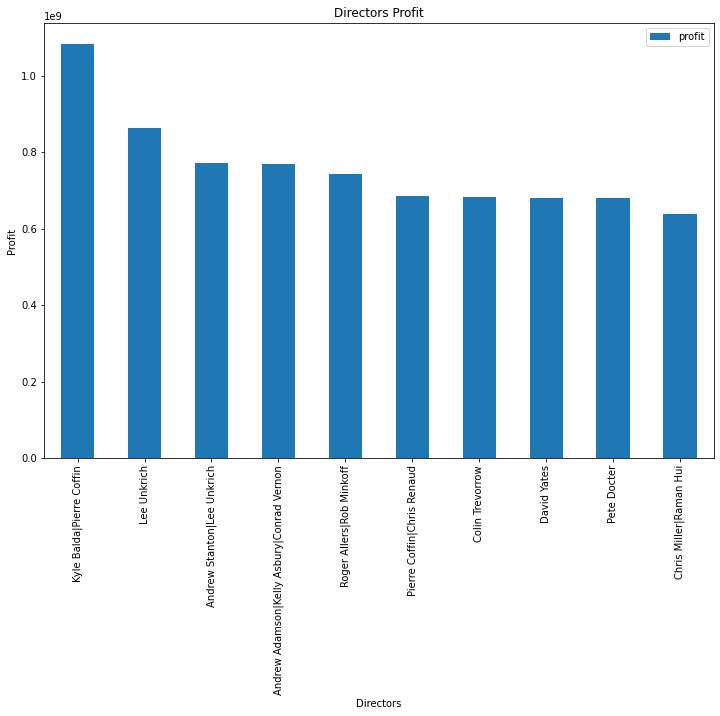

```python
ax = df2.plot.bar('director', 'profit', title= 'Directors Profit', figsize=(12,8), width=0.5);

ax.set_xlabel('Directors')
ax.set_ylabel('Profit');
```

Overview of budget, revenue and profit.

From the chart below, of the 10 high performing directors by profit, budget is neglible in comparison to revenue and profit they generate.

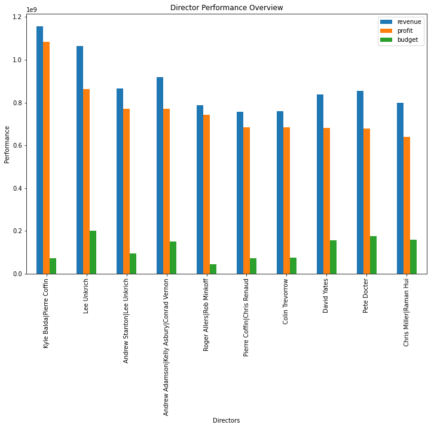

```python
df2[['director','revenue', 'profit', 'budget']].sort_values(by=['profit'], ascending=False).plot(
                                                        x='director',
                                                        kind='bar',
                                                        stacked=False,
                                                        figsize=(12,8),
                                                        title='Director Performance Overview',
                                                        xlabel='Directors',
                                                        ylabel='Performance'
                                                    );
```

High vote count can determine the quality of upcoming movies if production houses are able to rely on the voting done by the viewers.

The graph below shows directors all-time mean vote count from highest (approx. 4143) to the lowest (1277).

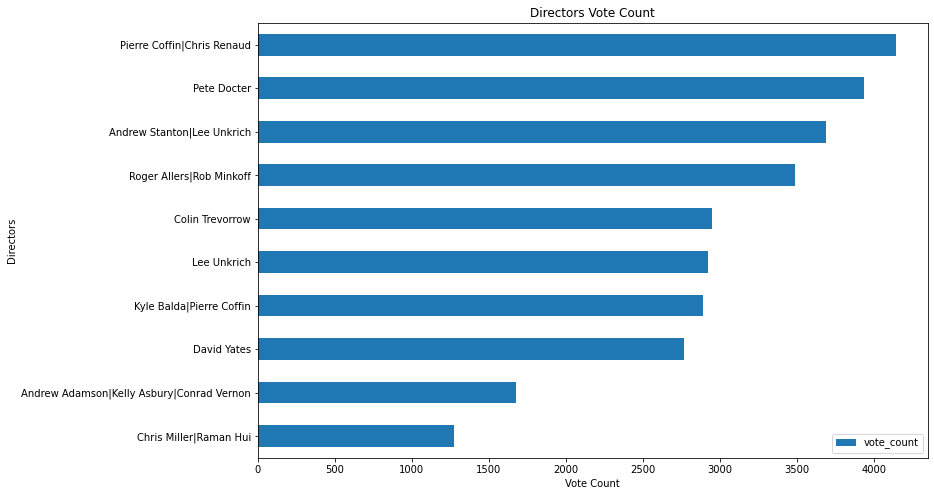

```python
ax = df2.sort_values(by=['vote_count']).plot.barh(
                                                    'director',
                                                    'vote_count',
                                                    title= 'Directors Vote Count', figsize=(12,8), width=0.5
                                                );

ax.set_xlabel('Vote Count')
ax.set_ylabel('Directors');
```

From the pie chart below, we can see popularity share percentage for each director.

This chart can be useful in assigning movie projects to high performing directors based on previous movies' popularity.

[figure not shown]

```python
df2.plot.pie(
    y='popularity',
    labels=df['director'],
    figsize=(12,7),
    autopct='%.2f',
    title='Director average film popularity',
    ylabel='',
    legend=False,
    wedgeprops={'edgecolor': 'white'}
);
```

While producing a movie, the cost of production should be kept low. From the graph below, we can be able to see average budget spending for the top 10 directors by profit.

**Roger Allers|Rob Minkoff** has the lowest budget out of the 10 directors while **Lee Unkrich** has the highest average budget spend.

Depending on available budget, production houses can base their decisions on the average spendings by the directors. This will ensure movie is produced without need for much additional budget.

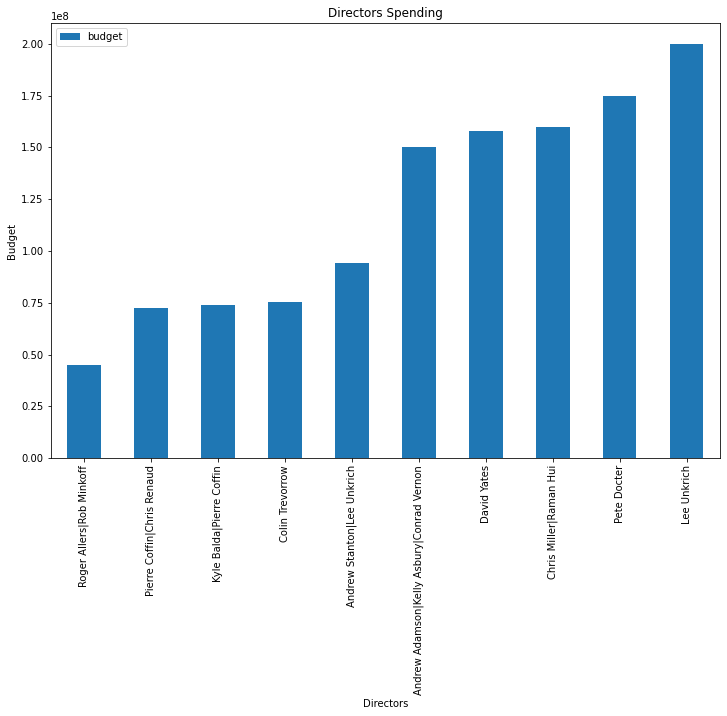

```python
ax = df2.sort_values(by=['budget']).plot.bar('director', 'budget', title= 'Directors Spending', figsize=(12,8), width=0.5);

ax.set_xlabel('Directors')
ax.set_ylabel('Budget');
```

## Conclusions

### Movie Release month

1. For optimal movie performance, producers should target their release dates on the months of:
   - May
   - June
   - December
   - July
2. Whenever possible, avoid releasing movies in the months:
   - January
   - September
   - August

### Best performing Directors

1. Highest Profit Margins directors To produce Movies with Highest Profit Margins, top 3 directors to use are:
   - Kyle Balda and Pierre Coffin
   - Lee Unkrich
   - Andrew Stanton and Lee Unkrich
2. Lowest Budget Directors When the budget is not high and the desired movie performance is high, directors below can deliver high performing movies at the lowest cost:
   - Roger Allers and Rob Minkoff
   - Pierre Coffin and Chris Renaud
   - Kyle Balda and Pierre Coffin
3. Popularity When marketing other movies within the platform, other factors of the movie can be ignored and popularity of the movie used for advertisement is prioritized. In these scenario, the below director can deliver:
   - Colin Trevorrow
   - Kyle Balda and Pierre Coffin
   - Pete Docter

Taking all the observations from point 1 to 3, **Kyle Balda and Pierre Coffin** can deliver high performing movie on low budget with high profit margin and popularity.

### Limitations

1. Individual director contribution to the film performance when a film is produced by more than one directors has not been calculated. Whenever a film is produced by more than one directors, my analysis treats multiple directors as it does with individual directors. In most instances, these directors have produced other films by themselves but my analysis does not factor in their contribution in other films where they produced a film with other directors.
2. The conclusions on best performing directors is based on top 10 movies per profit. This has ignored the fact that there can be higher performing directors for the popularity and budget when we eliminate the best 10 directors by profit condition.
3. Recommendations on film performance on the conclusion section above has ignored the fact that a combination of directors that have not worked together before can produce a high performing film.
4. Minimum number of film produced by director to be considered high performing has not been set. In the event that a director produced one high performing film, they will appear on the conclusion. In real life, this will not be accurate because:
   - The movie might have been released in months associated with high performance.
   - The director might have worked with high performing cast
   - Film story line might have been top notch

To achieve accurate conclusion, minimum number of film produced will atleast ensure that the actor has dealt with multiple scenarios and still performs.

Sources:

1. https://www.kaggle.com/datasets/tmdb/tmdb-movie-metadata
2. https://matplotlib.org/3.5.2/tutorials/introductory/pyplot.html
3. https://stackoverflow.com/questions/37625334/python-pandas-convert-month-int-to-month-name

```python
from subprocess import call
call(['python', '-m', 'nbconvert', 'Investigate_a_Dataset.ipynb'])
```